# 450 - Marketing Analytics - Solo 2

### For all respondents, do some attributes indicate strong preferences?

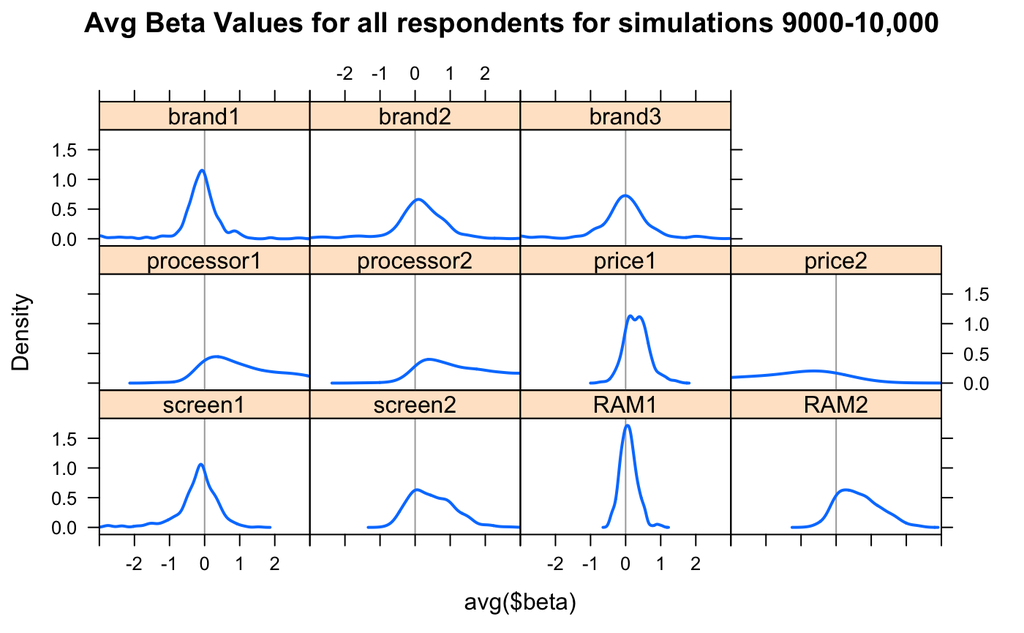

## Q4 - Study of price sensitivity by brands

| Interaction | USD.199 | USD.299 | USD.399 |
| --- | --- | --- | --- |
| STC : Somesong | 2.20 | 1.92 | 1.67 |
| STC : Pear | 1.64 | 1.41 | 1.22 |
| STC : Gaggle | 2.40 | 2.08 | 1.80 |

## Q5 - Impact of ownership of an STC product on the consumer preferences

The impact of previos STC ownership can be measured by introducing the binary variable `vList3` in the input data to the MNL model. The `rhierMnlDP` function outputs a variable called `Deltadraw` which helps us understand which attributes change the most when previous ownership of STC products is true. The graph below shows the values for the final 1000 simulation values (i.e. after removal of burn-in values), with the red points showing the average. What are some key takeaways? Previous ownership of STC makes:

- Respondents highly sensitivity to very high prices ($399)
- Respondents less likely to prefer Somesong (brand1) and Gaggle (brand3), yet, very likely to prefer Pear (brand2). This is a key insight - why would those who own STC want to switch over to Pear?
- Respondents more likely to want 2.5 GHz & 2 GHz processors, and 16 GB RAM
- Respondents less likely to prefer smaller 7 inch screens

Interpretation of the baseline levels for each attribute from this analysis is unknown.

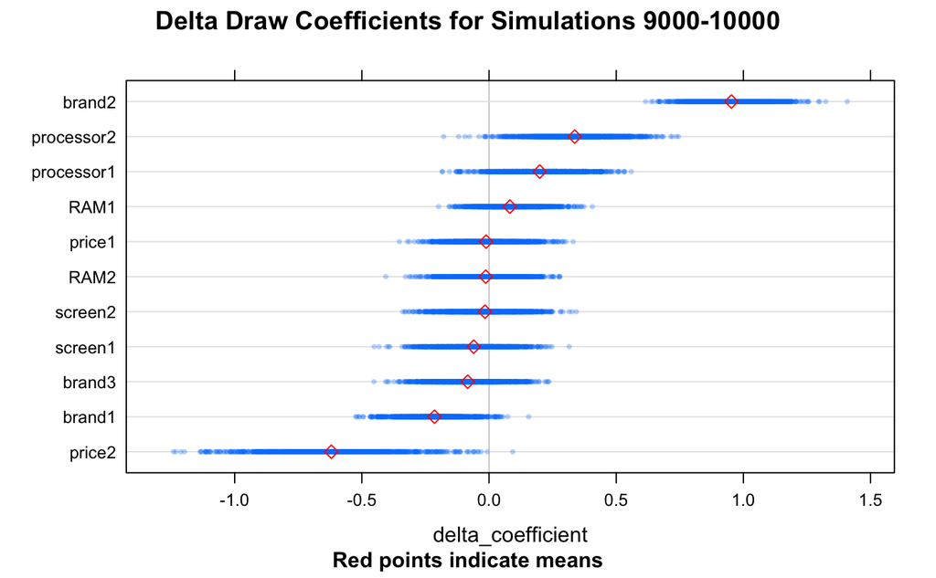

## Q6 - Prediction on additional scenarios

Obee has provided two more choice sets to perform predictions for, as shown in the table below. Applying the 1 predictive model developed using the overall averaged beta coefficients. The predicted probabilities of the choices shown in the table agree with the intuition we’ve developed in the model above. For choice set 1, a 68% probability is predicted for a largest screen, largest RAM, lowest price and STC brand, just as we expected. However, for choice set 2, the first two alternatives are almost all the lowest configurations for all attributes, and as a result it’s roughly a 50-50 chance of selection of either alternative 1 or 2. Not such a strong prediction.

| choice.set | screen | RAM | processor | price | brand | Prob Pred of Choice | Selected Choice |
| --- | --- | --- | --- | --- | --- | --- | --- |
| 1 | 2 | 0 | 1 | 0 | 3 | 0.07 |  |
| 1 | 2 | 2 | 1 | 0 | 0 | 0.68 | X |
| 1 | 2 | 1 | 1 | 0 | 2 | 0.24 |  |
| 2 | 0 | 0 | 0 | 0 | 0 | 0.51 | X |
| 2 | 0 | 1 | 0 | 0 | 3 | 0.48 |  |
| 2 | 1 | 1 | 0 | 2 | 2 | 0 |  |

## Q7 - Attribute level partworths calculations

Part worths are conceived to be latent values a customer places on levels of an attribute when making choices. Based on the model we’ve developed, we can calculate the point estimate of average part worth of each attribute, for each respondent. For example, the part worths for respondent 281 is shown in the figure below. This respondent has highest negative sensitivity to high prices, and brands Pear and Gaggle. This type of data can be generated for all respondents.

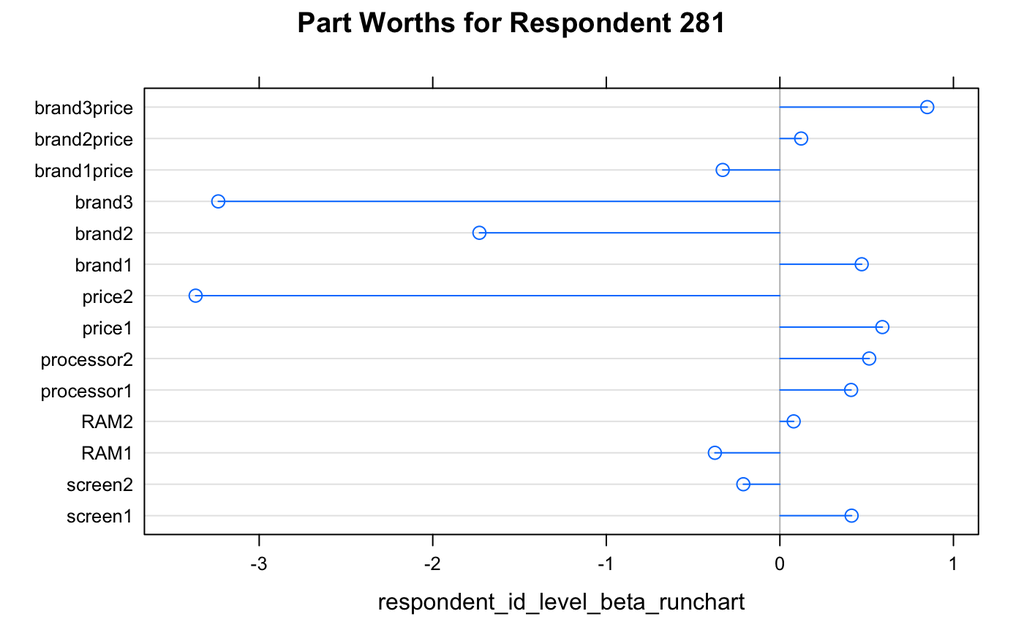

To calculate this, the following calculation must be run:

1. From the `HBMNL_obj` which is the model object, extract the `betadraw` component first. This will be a 3-D matrix, of dimension (respondent_size x #questions x #simulation_runs_saved). In our example, the size will be (424 x 14 x 10000).
2. Extract the respondent of interest by filtering on the 1st index. For example `HBMNL_obj$betadraw[respondent_id, , ]`. Now, we have 2-D object of dimension (#questions x #simulation_runs_saved).
3. Remove the number of columns based off of the burn off needed. In our example, this reduces (14 x 10000) to (14 x 1000).
4. Calculate the row-means to obtain the part-worth estimates for selected respondent. We will have 14 values corresponding to attributes + interaction terms.
5. Iterate steps 1-4 for desired respondent IDs.

## Q8 - Attribute importances for respondents

Since we use dummy coding, one level of each attribute is a base level. The beta coefficients that describe the part worth are with respect to this base level. Attribute importances can be calculated by performing the following algorithm:

1. Calculate each respondents part-worth estimates using the algorithm described in the section above. These will be beta estimates for the dummy variables.
2. For each attribute, add the missing base level. For ex: For {brand1, brand2, brand3}, add brand0 to the dataset.
3. The value for the base variable is equal to `-1* sum(level1, level2,...)`. So now, we have v1 = {brand0, brand1, brand2, brand3}.
4. Calculate odds ratio for each level as follows: v2 = {exp(brand0), exp(brand2), exp(brand3), exp(brand4)}.
5. The odds-ratio indicate how important the levels of the attributes are for that respondent. 1. The effect of moving from the base level to a different level can be computed using the formula exp(level_n - level_base). This can answer the question ‘How much more important is level_n compared to level_base?’

## Q10 - Comparison of Performance between two models

The covariate indicating prior STC ownership is not significant to the model. A comparison of the performance estimates of both models indicate no difference in the models, when comparing metrics like accuracy or AUC. The AUC for the ROC for both models is 0.863. The accuracy and kappa values are quite similar too, as seen below.

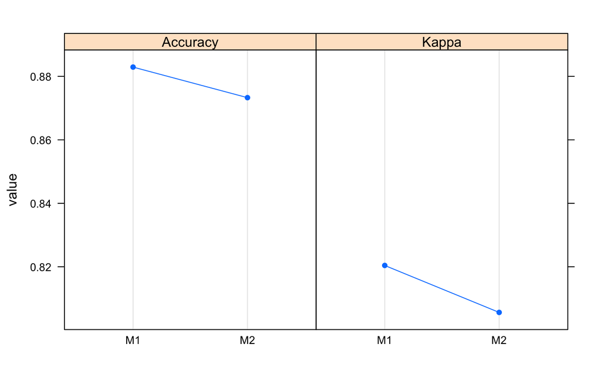

# Final Recommendation to STC

Based on all the analysis performed thus far, the recommendations to Obee would to be to develop the following product configuration:

- Price - Lowest (USD 199)
- Brand - STC
- Processor - 2.5 GHz
- RAM - 32 GB
- Screen - 10 inch

The analysis results in Q3 and Q5 support this conclusion. Given the respondents view of STC as the strongest brand, STC is well positioned as a brand to enter the mobile computing market. The price sensitivity was glaringly obvious through all the analyses, and STC should strive to develop at product at the $199 price point only. RAM should be targeted at 32 GB. While existing STC owners are not sensitive between 16 and 32 GB, when all the respondents are seen on aggregate, the response is strongly skewed towards the largest RAM size. The largest screen is also very strongly preferred by a majority of the respondents.

Like any analysis, the outputs are only as good as the input data. A few watchouts for STC to keep in mind are that these analyses are currently only validated on internal data. It would behoove the company to perform some external / hold out style validation as well. Deeper dives into some of the choice sets which predict poorly need to be performed. Perhaps there is some bad data in the overall set. Investigation of other covariates which may add differenciation in product configuration (demographics etc) may add value. There can also some clustering work to be done on the remainder of the dataset not used in this exercise. Simulation ‘what if’ exercises can answer some questions, and further validation of the selected product can be performed via focus groups or beta-releases into a test market.